# An exploration of Wine Quality by James Cooper

# Univariate Analysis

STRUCTURE:

```
## 'data.frame':    1599 obs. of  13 variables:
##  $ X                   : int  1 2 3 4 5 6 7 8 9 10 ...
##  $ fixed.acidity       : num  7.4 7.8 7.8 11.2 7.4 7.4 7.9 7.3 7.8 7.5 ...
##  $ volatile.acidity    : num  0.7 0.88 0.76 0.28 0.7 0.66 0.6 0.65 0.58 0.5 ...
##  $ citric.acid         : num  0 0 0.04 0.56 0 0 0.06 0 0.02 0.36 ...
##  $ residual.sugar      : num  1.9 2.6 2.3 1.9 1.9 1.8 1.6 1.2 2 6.1 ...
##  $ chlorides           : num  0.076 0.098 0.092 0.075 0.076 0.075 0.069 0.065 0.073 0.071 ...
##  $ free.sulfur.dioxide : num  11 25 15 17 11 13 15 15 9 17 ...
##  $ total.sulfur.dioxide: num  34 67 54 60 34 40 59 21 18 102 ...
##  $ density             : num  0.998 0.997 0.997 0.998 0.998 ...
##  $ pH                  : num  3.51 3.2 3.26 3.16 3.51 3.51 3.3 3.39 3.36 3.35 ...
##  $ sulphates           : num  0.56 0.68 0.65 0.58 0.56 0.56 0.46 0.47 0.57 0.8 ...
##  $ alcohol             : num  9.4 9.8 9.8 9.8 9.4 9.4 9.4 10 9.5 10.5 ...
##  $ quality             : int  5 5 5 6 5 5 5 7 7 5 ...
```

### What is the structure of your dataset?

The following information taken directly from https://s3.amazonaws.com/udacity-hosted-downloads/ud651/wineQualityInfo.txt

Description of Input Variables

1 - fixed acidity: most acids involved with wine or fixed or nonvolatile (do not evaporate readily)

2 - volatile acidity: the amount of acetic acid in wine, which at too high of levels can lead to an unpleasant, vinegar taste

3 - citric acid: found in small quantities, citric acid can add ‘freshness’ and flavor to wines

4 - residual sugar: the amount of sugar remaining after fermentation stops, it’s rare to find wines with less than 1 gram/liter and wines with greater than 45 grams/liter are considered sweet

5 - chlorides: the amount of salt in the wine

6 - free sulfur dioxide: the free form of SO2 exists in equilibrium between molecular SO2 (as a dissolved gas) and bisulfite ion; it prevents microbial growth and the oxidation of wine

7 - total sulfur dioxide: amount of free and bound forms of S02; in low concentrations, SO2 is mostly undetectable in wine, but at free SO2 concentrations over 50 ppm, SO2 becomes evident in the nose and taste of wine

8 - density: the density of water is close to that of water depending on the percent alcohol and sugar content

9 - pH: describes how acidic or basic a wine is on a scale from 0 (very acidic) to 14 (very basic); most wines are between 3-4 on the pH scale

10 - sulphates: a wine additive which can contribute to sulfur dioxide gas (S02) levels, wich acts as an antimicrobial and antioxidant

11 - alcohol: the percent alcohol content of the wine

Output variable (based on sensory data):

12 - quality (score between 0 and 10)

An interesting note is that the authors point out that they are unsure whether all the input variable are relevant. If too many variables with a high correlation are left in this could harm the regression.

### What is/are the main feature(s) of interest in your dataset?

Main feature of interest is the quality scores as this is the output variable. The main point of this exploration is to find out which input variables are useful predictors of quality.This is of course subject to the major caveat that Quality itself is not an objective measure, and furthermore that the quality of this non- objective measure (a wine experts ability to consistently and accurately grade wine in a controlled blind environment) has been called into question (read: completely debunked) by numerous recent studies.

www.theguardian.com/lifeandstyle/2013/jun/23/wine-tasting-junk-science-analysis

### What other features in the dataset do you think will help support your ###investigation into your feature(s) of interest?

I think that the outliers will provide a useful insight into the grades received. I would expect that the wines with a massive concentration of salt / acid would tend towards lower scores.

### Did you create any new variables from existing variables in the dataset?

No - I felt that whilst this woud be possible ( IE create bound S02 measure by subtracting free SO2 from total S02), I felt that this was unlikely to provide any extra insight. After all, the curators have not included it in the dataset - I am assuming they know more about wine than me.

### Of the features you investigated, were there any unusual distributions?

Did you perform any operations on the data to tidy, adjust, or change the form  
of the data? If so, why did you do this?

# Bivariate Plots Section

QUALITY VERSUS FREE SO2

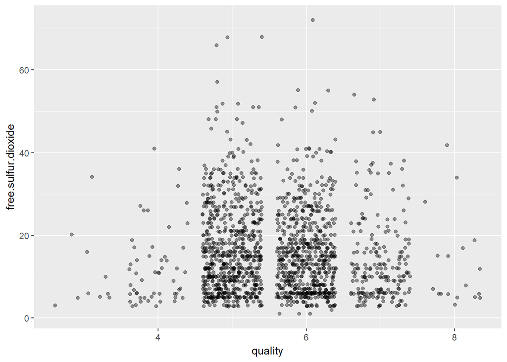

This doesn’t really show a clear relationship - there are so many more observations for quality 5 and 6 wines that it is difficult to get a feel for the data.

QUALITY VERSUS Total SO2

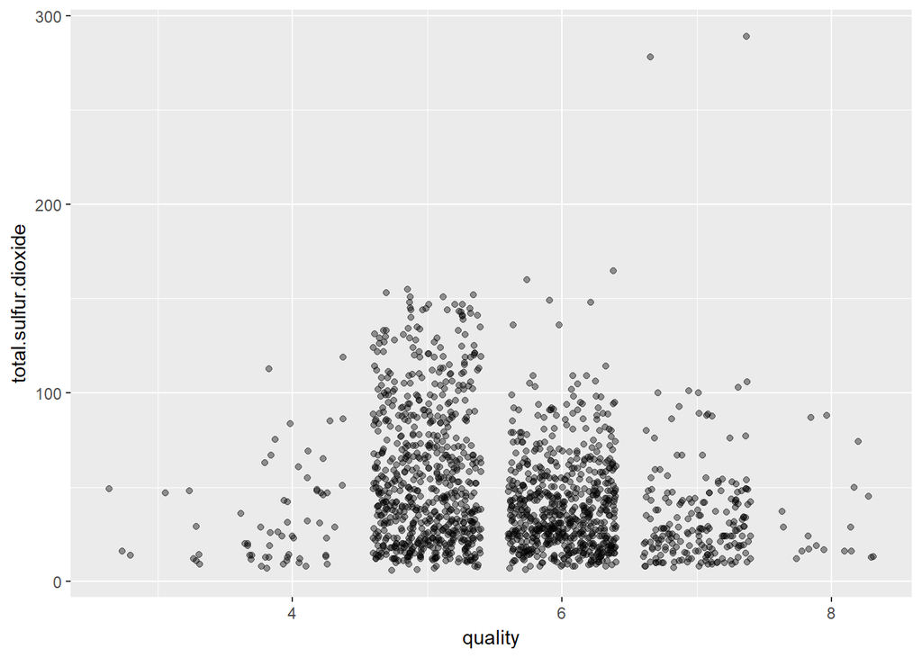

THese graphs don’t really show us too much however of some note are the 2 outliers that got a 7 in taste despite havingthe highest So2 scores. THis seems odd!

REVISITNG Q VS FREE SO2 and Q vs bound SO2 - this time using boxplots.

QUALITY VERSUS free SO2 2

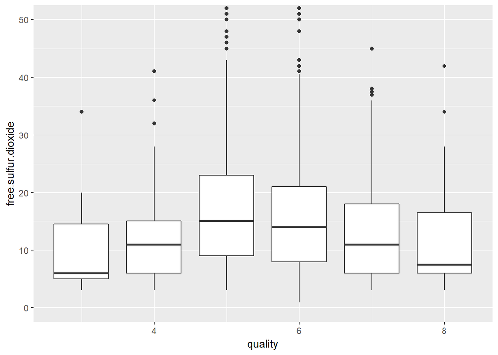

Quality versus total So2 2

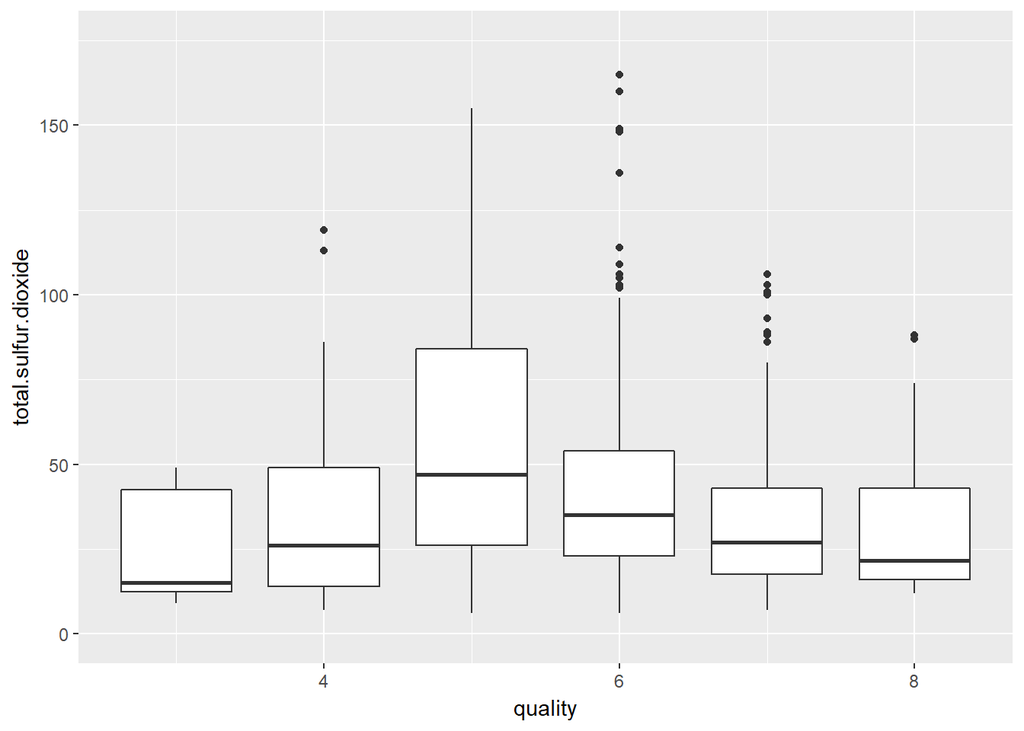

Note the mean similarities.

```
##
##  Pearson's product-moment correlation
##
## data:  free.sulfur.dioxide and quality
## t = -2.0269, df = 1597, p-value = 0.04283
## alternative hypothesis: true correlation is not equal to 0
## 95 percent confidence interval:
##  -0.099430290 -0.001638987
## sample estimates:
##         cor
## -0.05065606
```

```
##
##  Pearson's product-moment correlation
##
## data:  total.sulfur.dioxide and quality
## t = -7.5271, df = 1597, p-value = 8.622e-14
## alternative hypothesis: true correlation is not equal to 0
## 95 percent confidence interval:
##  -0.2320162 -0.1373252
## sample estimates:
##        cor
## -0.1851003
```

There is a relationship here, but it is extremely weak. This means that 1. Outliers are masking due to experimenal error or 2. other factors are masking this due to interrelationships between variables.

We can at least address the first one by removing the outliers. Let’s see what effect that has.There are mutiple ways to do this. I will simply exclude FSO over 60.

```
##
##  Pearson's product-moment correlation
##
## data:  free.sulfur.dioxide and quality
## t = -1.8543, df = 1593, p-value = 0.06387
## alternative hypothesis: true correlation is not equal to 0
## 95 percent confidence interval:
##  -0.095275874  0.002678368
## sample estimates:
##         cor
## -0.04641032
```

Excluding outliers actually reduces the correlation for Fs02.

And for Total FS02:

```
##
##  Pearson's product-moment correlation
##
## data:  total.sulfur.dioxide and quality
## t = -8.4748, df = 1595, p-value < 2.2e-16
## alternative hypothesis: true correlation is not equal to 0
## 95 percent confidence interval:
##  -0.2540458 -0.1601596
## sample estimates:
##        cor
## -0.2075807
```

On the other hand, exluding the outliers actually strengthens the relationship between TSO2 and quality.

THis is a bit confusing - the wording used in the model implied that there would be a negative impact on the taste of the wine based on the free rather than total sulphur content. However there are several other variables at work here and it is possible that this is simply not a major factor relative to them. Before giving up on this line of inquiry I will attempt to examine this one last time.

I am going to take an average of the Quality score for each concentration, flipping the chart in the process.

I will use Dplyr to group by free.sulfur.dioxide.

```
## # A tibble: 6 x 4
##   free.sulfur.dioxide quality_mean quality_median     n
##                 <dbl>        <dbl>          <dbl> <int>
## 1                 1.0     6.000000              6     3
## 2                 2.0     6.000000              6     1
## 3                 3.0     5.755102              6    49
## 4                 4.0     5.487805              5    41
## 5                 5.0     5.538462              5   104
## 6                 5.5     6.000000              6     1
```

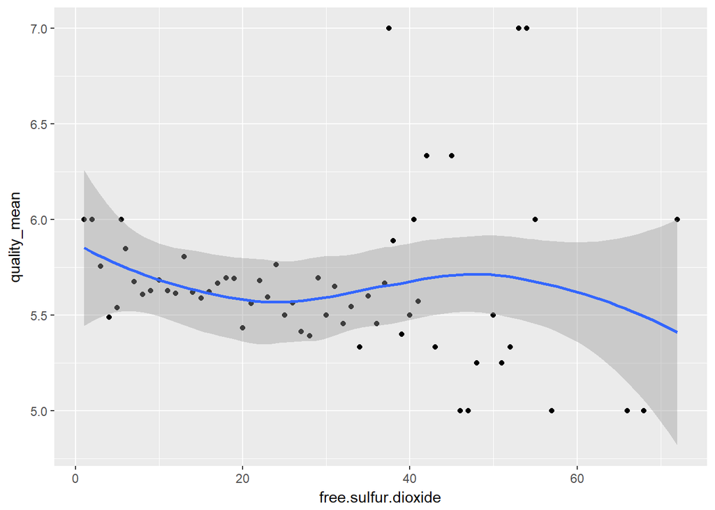

THere is a lot of variance introduced by individual readings. If we round FSO we can smooth some of this out to see if the relationship becomes a little clearer.

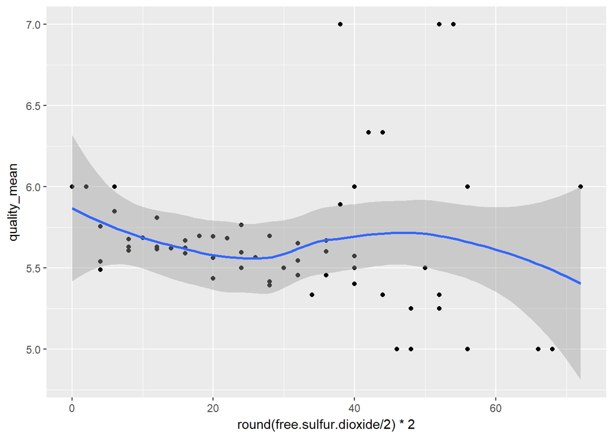

Unfortunately this approach does not really give us a smoother line as expected.

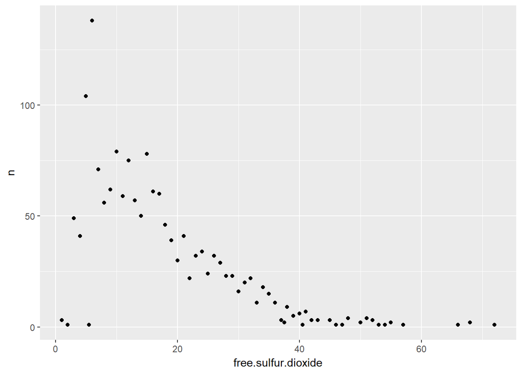

There is also a massive difference in the number of observations for each concentration. Clearly the means for the quality of the higher concentrations of SO2 are going to be much less accurate than those on the lower end.

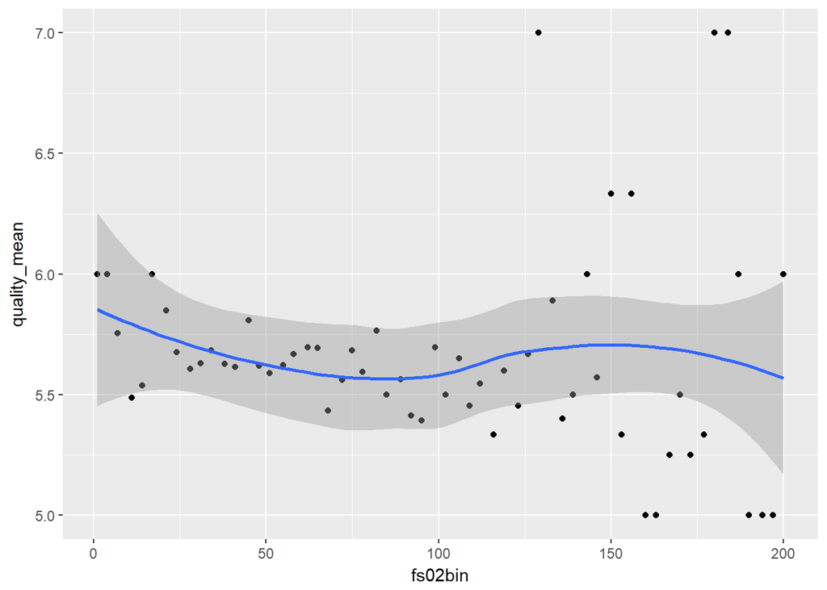

This was the first attempt to bin FS02 - it failed.

I will come back to this graph as it raises some interesting questions.

For now I will end the exploration of FS02 by itself by examining the median rather than the mean.

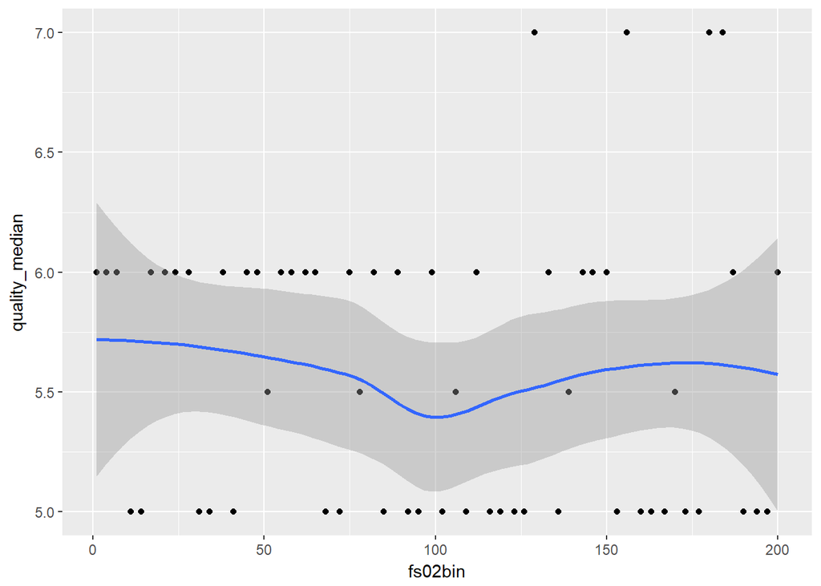

I should have known that this would not provide any useful insight.

Let’s take a step back and see how TSO2 and FSO2 are related:

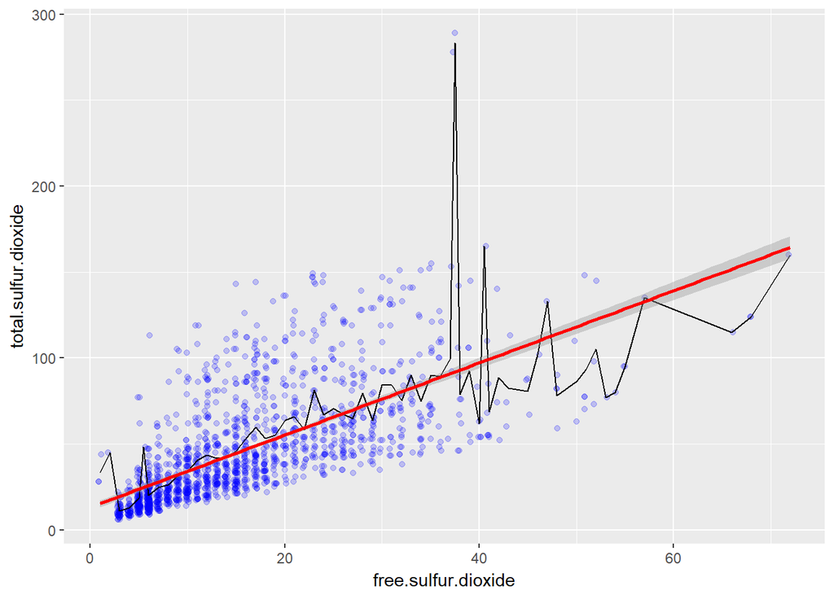

One interesting thing about the boxplots further above is that the free and total S02 appear to show similar distributions, if we look at the mean for each quality level.This appears to be consistent with the fact that they are moderately correlated with each other, as demonstrated here.

Corr to confirm:

```
##
##  Pearson's product-moment correlation
##
## data:  free.sulfur.dioxide and total.sulfur.dioxide
## t = 35.84, df = 1597, p-value < 2.2e-16
## alternative hypothesis: true correlation is not equal to 0
## 95 percent confidence interval:
##  0.6395786 0.6939740
## sample estimates:
##       cor
## 0.6676665
```

Moderate level of correlation. I was actually expecting this to be higher.

I am now going to repeat the exploration that I did for FSO2 for total FSO2. Seeing as the two variables are correlated, and that the correlation was stronger between total FS02 and Quality versus free S02 and quality, this means that it is more likely we will be able to tease out the relationship from our graphs.

This time to avoid getting caught out I’ll plot the distributions of observations first.

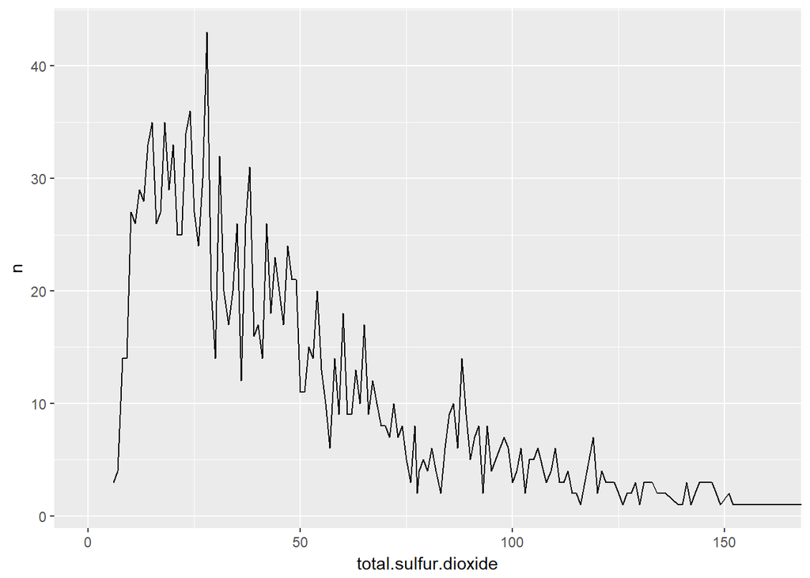

Again we see that the lower concentrations are more highly represented in the data than the higher observations.

I have a feeling I used the wrong approach to address this earlier. Rather than grouping by FS02 score, I should have first created a new variable in the original dataframe to assign each observation a percentile FSO2. THen I could group by THAT, and the resulting graph would be adjusted for frequency.

The next couple of graphs I will remedy this mistake and also investigate TOTAL FS02.

ok, now , lets revisit Fs02 (the pfree variable is the percentile of Fs02):

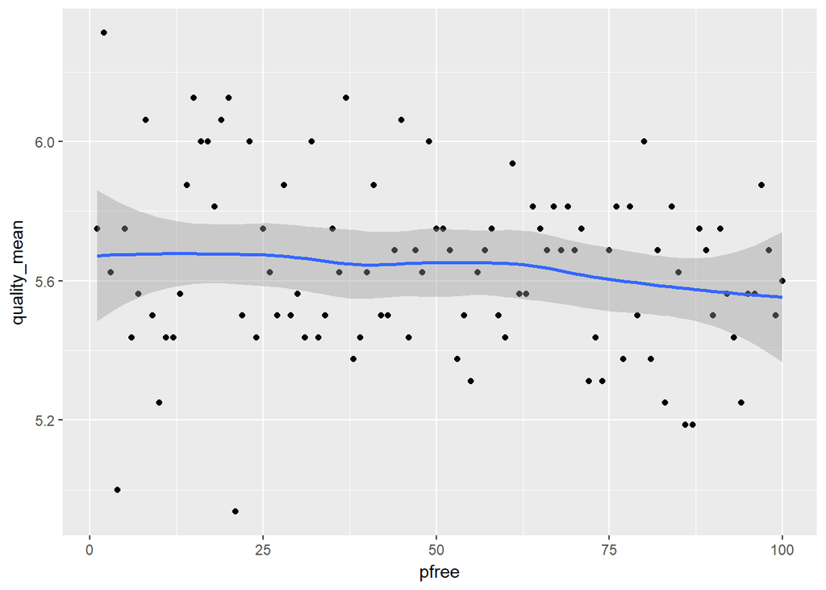

Well, now we can see clearly what was already confirmed in the correlation - there isn’t really a relationship between free S02 and Quality.

Now I will repeat the processs for Total Fs02. First I will show the old way (without adjusting for n)

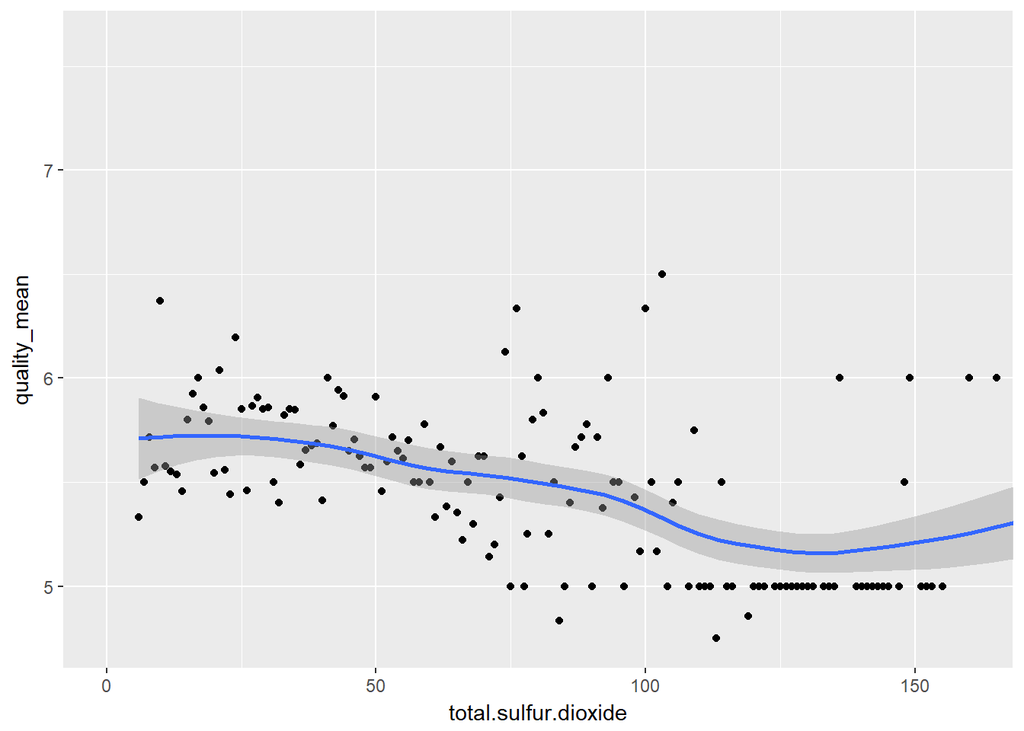

As discussed before, it is difficult to extract meaning from this graph because we know that some points are more valid than others, specifically the higher TS02 concentraions tend to be based on less observations. There is a vague trend downward but it isn’t very steep, and it appears to start to increase!

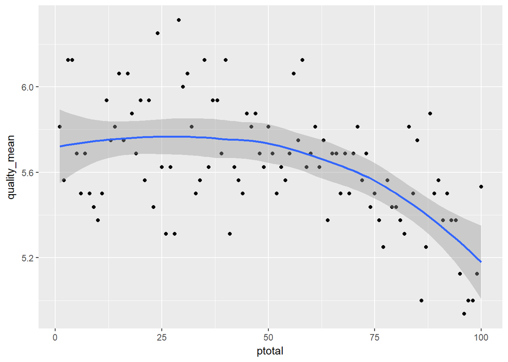

After adjusting for n and fitting our smoothedline we can now see a reasonably clear, extremely weak negative relationship!

Not only that, but we can also see a slight drop at the lower end of the concentration scale - could this be because more microbes were present to spoil the wine?

I am quite pleased with the above methodology, as it can now be applied easily to two other variables that I want to explore: Acetic acid concentration (variable = volatile acidity) and Citric acid concentration.

Based on the descriptions of these variables, I would expect Acetic acid to be negatively correlated with quality, and Citric acid to be positively correlated.

Acetic Acid Exploration:

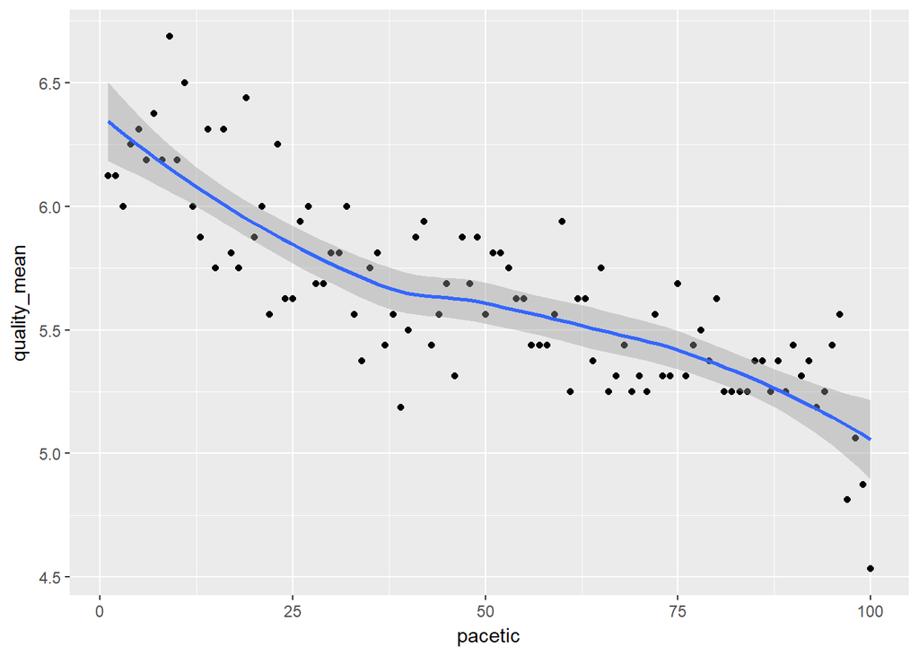

A nice clear, negative correlation, as we expected.

To confirm:

```
##
##  Pearson's product-moment correlation
##
## data:  volatile.acidity and quality
## t = -16.954, df = 1597, p-value < 2.2e-16
## alternative hypothesis: true correlation is not equal to 0
## 95 percent confidence interval:
##  -0.4313210 -0.3482032
## sample estimates:
##        cor
## -0.3905578
```

On to Citric Acid:

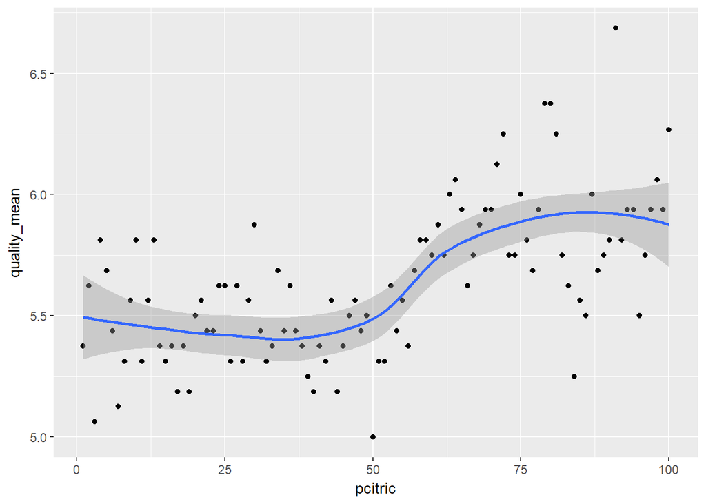

We see again a nice clear relationship that fits with the description of Citric acid as being associated with positive qualities. It is possible that there is a curve because the perception of “Freshness” by the taster is only possible above certain concentrations of Citric acid?

The positive correlation is confirmed below:

```
##
##  Pearson's product-moment correlation
##
## data:  citric.acid and quality
## t = 9.2875, df = 1597, p-value < 2.2e-16
## alternative hypothesis: true correlation is not equal to 0
## 95 percent confidence interval:
##  0.1793415 0.2723711
## sample estimates:
##       cor
## 0.2263725
```

# Bivariate Analysis

### Talk about some of the relationships you observed

The relationships I investigated were:

Free S02 versus quality

Total S02 versus quality

Free S02 versus Total S02

Volatile acid versus quality

Citric acid versus quality.

The main result of the investigation was that Acetic acid was moderately correlated with a decline in quality. There wasn’t a relationship between free SO2 and quality as the description of the Total S02 variable would suggest. Confusingly however, the TS02 variable was weakly correlated with quality, and there was a a moderate correlation between Free So2 and Total So2.

### What was the strongest relationship you found?

The above.

# Multivariate Plots Section

I will start by creating a new categorical variable based on quality score. This will allow us to combine this with our other numberic data in the same plot.

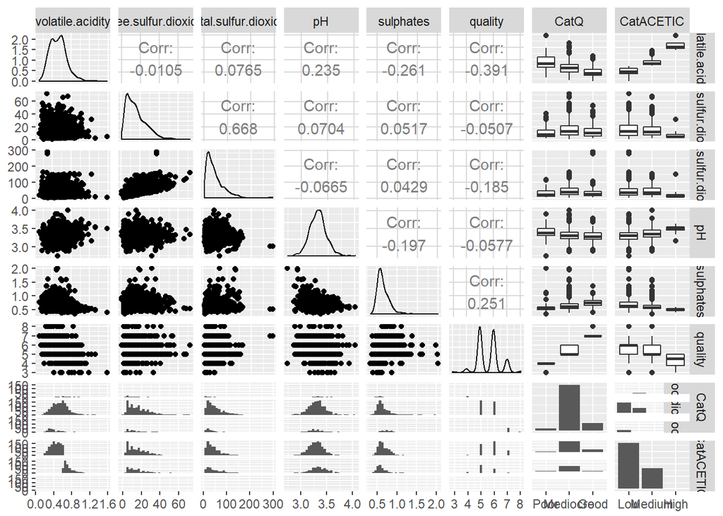

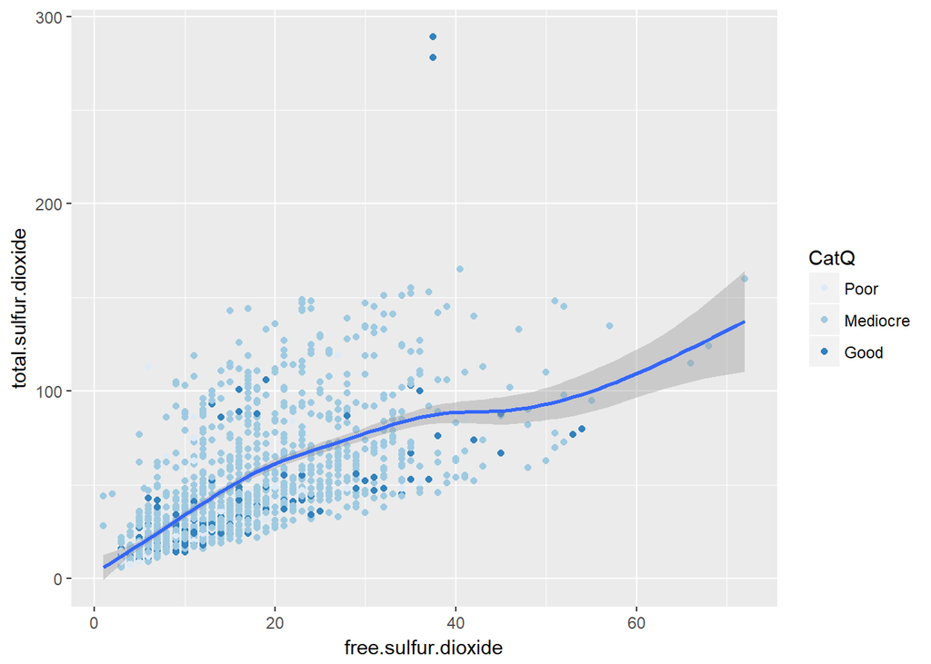

As previously established, FSO2 and TS02 are linked.

We know that both distributions are skewed, however. This will impact readability.

Lets try taking the log of both variables and see if anything jumps out to relate the ratio of these two variables to quality:

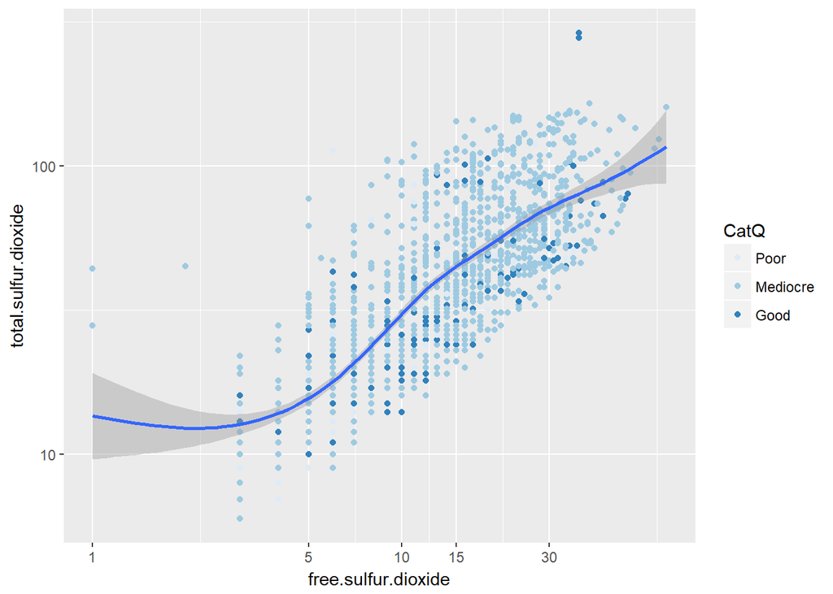

The majority of the Good quality wines appear to fall below the line of best fit - this is worth looking into further; I will come back to this in my final graphs.

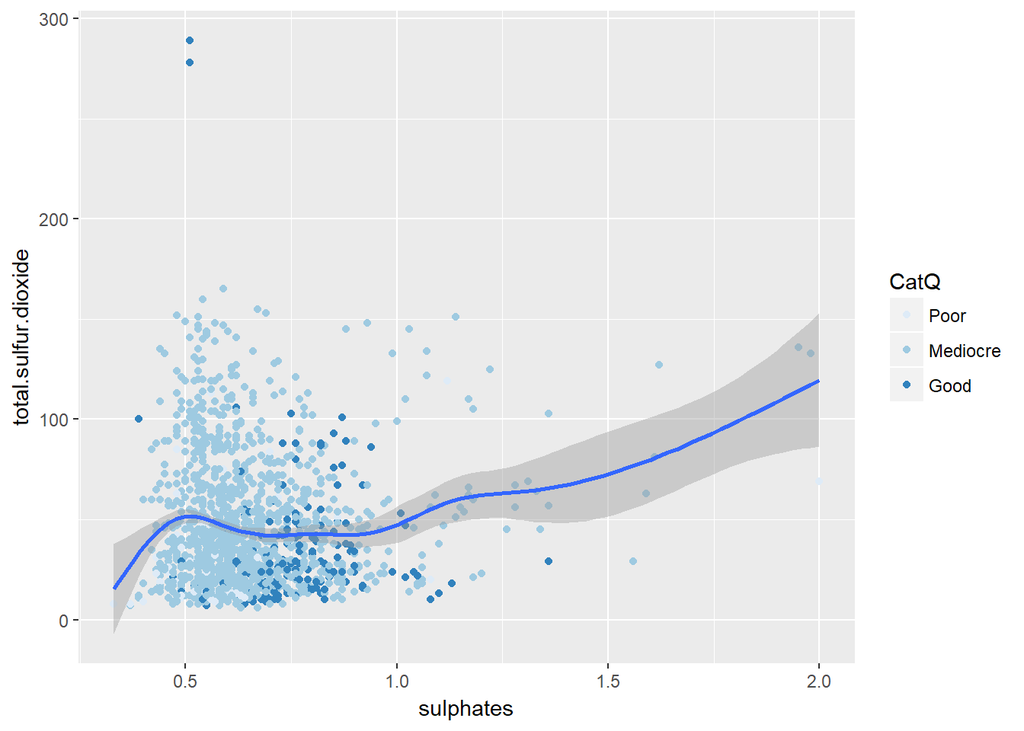

I was hoping to shed some light on the interrelationship of the Sulphate variable with TSO2, but there doesn’t seem to be a clear pattern here.

Taking the log of both sulphats and TS02:

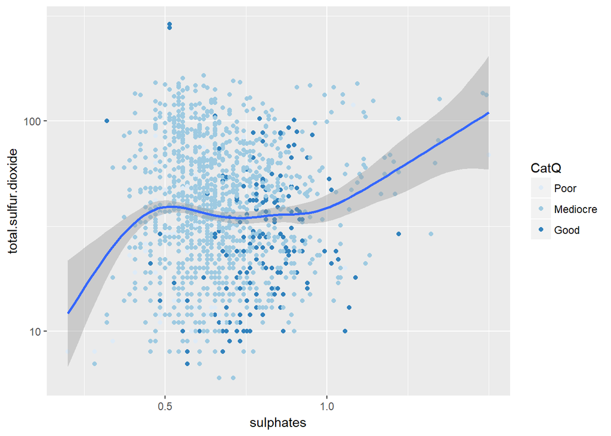

Lets try using the Y variable as output, in this case quality. Given that we have the highest correlations between quality and these two variables.

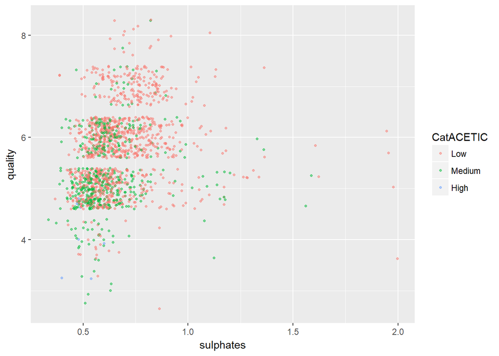

What about log sulfates? We know we have a skewed distribution of Sulphates, so transforming could give us a clearer idea of what’s going on:

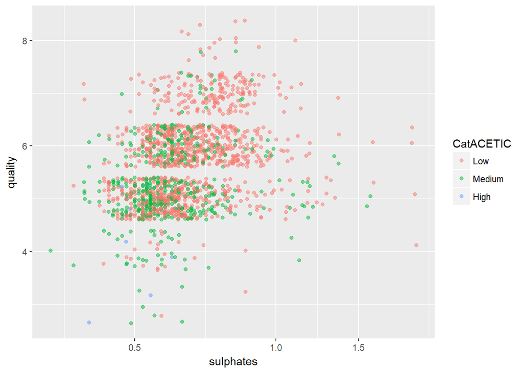

This is a bit clearer. Quality has a positive association with Sulphates - we see this reflected in that there is a slight creeping left to right as we move up quality. The negative relationship between Volatility and quality is also apparent in that we see more green and blue further down the quality scale.

# Multivariate Analysis

### Talk about some of the relationships you observed in this part of the investigation. Were there features that strengthened each other in terms of looking at your feature(s) of interest?

The ratio of mean log FSO2 to mean log TS02 appears to have a minor effect. Noticeablymore of the high quality wines showed up at the lower end.

### Were there any interesting or surprising interactions between features?

I was surprised that there were no high acetic acid concentrations at higher sulfate concentrations.

### OPTIONAL: Did you create any models with your dataset? Discuss the strengths and limitations of your model.

# Final Plots and Summary

### Plot One

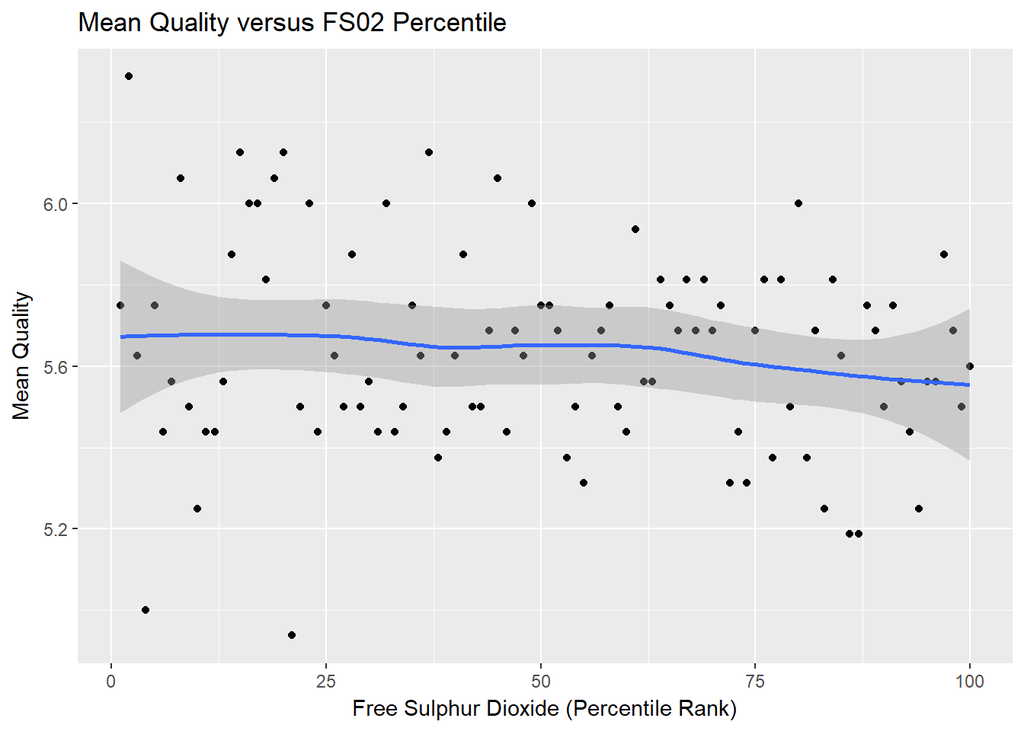

### Description One

This graph establishes that despite the information provided there isn’t a relationship between FS02 and Quality.

### Plot Two

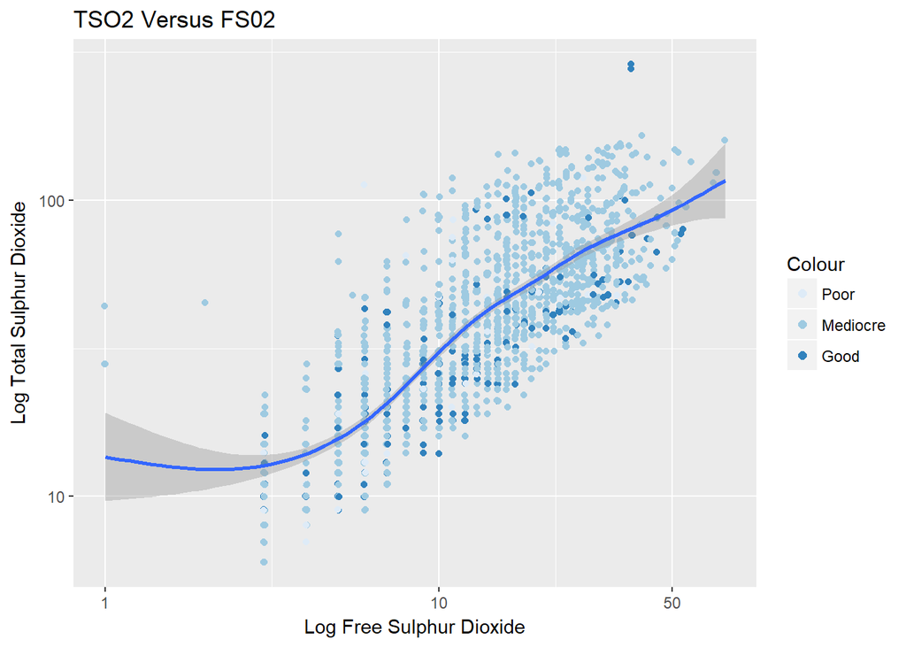

### Plot Three

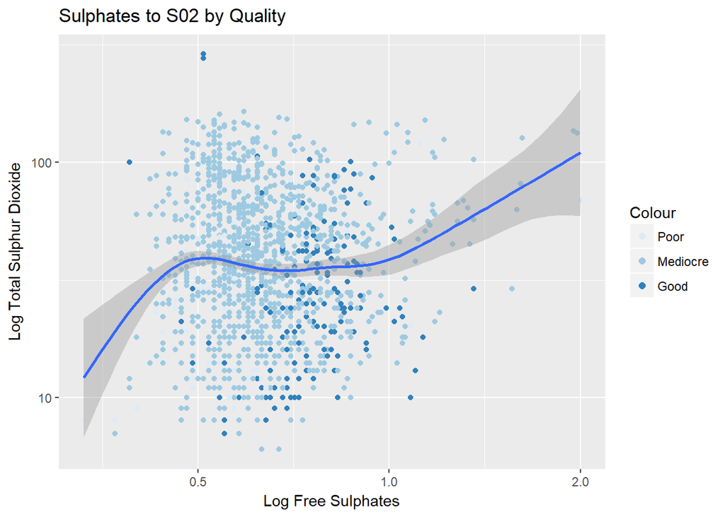

### Description Three

The graph shows little clear relationship between the variables, though there is a cluster of poor quality wines at low levels of both Sulphates and Sulphur Dioxide. ——

# Reflection

Overall I would say that despite the lack of a continuous output variable and my overall unfamiliarity with wine I was able to explore several interesting aspects of the data, in particular testing what appear to be inaccurate assumptions about how several variables would relate to quality based on the descriptions provided.

The major hurdle in this project was grappling with the inherent biases of the distributions and finding a clear way of accounting for this.

My background reading on the topic revealed that wine is an incredibly complex product, so there are many many more chemical variables to explore. Moreover as mentioned previously, the output metric - quality is very questionable given the evidence against the ability of wine tasters to consistently grade wines. However it should be noted that the quality metric used in this dataset is itself a median, and the gradings are rather broad, so this would offset any inaccuracy and still provide a good general sense of whether a wine is good or not.